# ISONE DA LMP Futures Settlement Model

Author

Nate Garozzo

Published

June 26, 2026

## 1 Introduction

Consumers use ISONE DA LMP (ISO-New England Day-Ahead locational marginal pricing) futures to hedge forward electricity expenses. However, the individual futures contract price on any given day provides no extra information about the distribution of expected outcomes for the settled price of the contract. Trained on historical daily futures and settlement data from 2022-2026, this model produces a predictive distribution for a base case (50th percentile), best case (5th percentile) and worst case (90th percentile) settled price outcome for consumers, given a particular day’s futures contract price, settlement month, and time to settlement (horizon). Linear regression is used to estimate the conditional mean forecast error ($/MWh), and a Gamma GLM is used to estimate the conditional variance. Finally, a Monte Carlo simulation is layered in to produce the distribution of expected outcomes. The goal for this model is to provide energy consumers in the ISONE territory with a better understanding of their forecasted expenses and whether or not they should be hedging their energy consumption.

## 2 Data

There are three primary data sets used in this analysis. The first contains the average monthly settled DA LMP in ISONE for every month from 2013-2026. After data wrangling and tidying, the cleaned data is structured as in the following sample:

| Month | Year | Settled Avg DA LMP |
| --- | --- | --- |
| Jan | 2018 | 62.34 |
| Jul | 2025 | 38.17 |

The next two contain the off-peak and peak daily settled monthly average futures contract prices (as far as 85 months ahead) from November 2022 to June 2026. For the purposes of simplifying the model training process, the off-peak and peak daily futures prices were averaged into a single futures contract price point. Below is another sample of the cleaned data:

| Current Month | Current Day | Current Year | Delivery Month | Delivery Year | Futures Price |
| --- | --- | --- | --- | --- | --- |
| Jan | 3 | 2023 | Jun | 2023 | 45.20 |
| Mar | 15 | 2024 | Dec | 2024 | 78.55 |

Merging these data frames, we can calculate the error ($\text{realized price - futures price}$) for every daily futures price prediction based on its settled monthly average DA LMP:

| Cur. Month | Cur. Day | Cur. Year | Del. Month | Del. Year | Futures Price | Error | Months Out |
| --- | --- | --- | --- | --- | --- | --- | --- |
| Jan | 3 | 2023 | Jun | 2023 | 45.20 | -3.42 | 5 |
| Mar | 15 | 2024 | Dec | 2024 | 78.55 | 12.18 | 9 |

Since the original data sets did not overlap from 2013-2021, there were several observations with no error value. These were subsequently filtered out, as well as any contracts that were either expired or purchased during the delivery month ($\text{months out < 1}$). Additionally, any combinations of month and horizon (ex: October 8 months out) that had less than 20 historical observations were removed from the data set.

## 3 Methodology

Forecasting price ranges poses several challenges. First, observations taken on consecutive days are highly autocorrelated. If the error is large and positive on May 15, the error is also likely to be large and positive on May 16. Rather than modeling the time series of the errors directly, this model takes a different approach, treating each observation as a draw from a distribution defined by its delivery month and time to expiration. This does not solve the autocorrelation problem since consecutive observations in the training data remain correlated. However, a rolling mean error adjustment partially addresses this issue by conditioning the mean error prediction on the average of the six most recent observed errors for each delivery month. These observations come from consecutive trading days, so the rolling mean captures the most recent bias level for that month (rather than six independent data points) and uses it to adjust the predicted mean error.

A second challenge is seasonal variation in price levels and forecast uncertainty. Winter months display much higher volatility than summer months, which is explained largely by the sensitivity of New England electricity prices to natural gas markets (which are volatile during the winter months due to cold weather). A model which assumes constant volatility/standard deviation in settled price for each month of the year would severely misrepresent the risk in several delivery months.

The model has three primary components:

1. A linear regression estimates the conditional mean forecast error as a function of delivery month and months to expiration

$$\hat{\mu}_{m,H} = \alpha_m + \beta_ms(h) + \lambda\bar{e}_{m,t}$$

where:

- $\hat{\mu}_{m,h}$ is the predicted mean forecast error for delivery month $m$ at horizon $h$
- $\alpha_m$ is a month-specific intercept
- $\beta_m$ is a month-specific slope on the natural cubic spline of time to expiration
- $h$ is months to expiration
- $s(h)$ is a natural cubic spline evaluated at horizon h with 6 degrees of freedom
- $\lambda$ is the coefficient on the rolling mean error
- $\bar{e}_{m,t}$ is the rolling mean of the six most recent observed errors for delivery month $m$ as of observation date $t$

Taking $s(h)$ as opposed to using $h$ directly is driven by a nonlinear relationship between forecast error and time to maturity. With the natural cubic spline, the curve is shaped by the data itself.

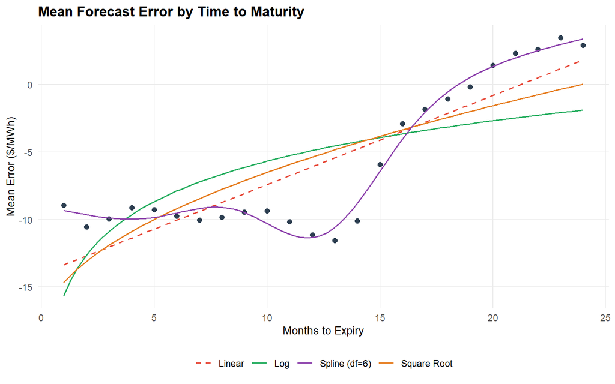

2. A Gamma Generalized linear model (GLM) is used to estimate the conditional variance of forecast errors as a function of delivery month, months to expiration, **and futures price**

$$\log(\hat{\sigma}^2_{m,h,f}) = \gamma_m + \delta_m s(h) + \phi f$$
where:

- $\hat{\sigma}^2_{m,h,f}$ is the predicted error variance for delivery month $m$, horizon $h$, and futures price $f$
- $\gamma_m$ is a month-specific intercept
- $\delta_m$ is a month-specific slope on the natural cubic spline of time to maturity
- $\phi$ is the coefficient on futures price $f$
- $s(h)$ is a natural cubic spline evaluated at horizon h with 6 degrees of freedom
- The log link $\log(\hat{\sigma}^2_{m,h,f})$ guarantee that the variance will be strictly positive

  Looking at a plot of the squared residuals from the error model ($\text{residual}^2 = (e_{m,h} - \mu_{m,h})^2$), we can see that the distribution roughly follows that of a Gamma distribution, which is strictly positive and right-skewed.

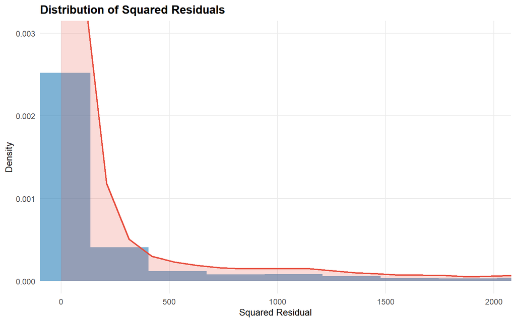

Similar to the error model, a natural cubic spline was used, driven by a nonlinear relationship between months to expiration and the standard deviation of residuals. A January contract 1 month out is being priced in December, when weather forecasts are volatile and a cold snap can drive up natural gas demand rapidly. However, a January contract 12 months out has a much more “general winter” expectation and there is plenty of time for the market to adjust to conditions. After fitting various functions to the scatter plot of the relationship between horizon and error, the natural cubic spline with $df = 6$ was selected. The spline flexibility captures the wave-like pattern in the data. A sine function was considered due to this wave pattern, but it did not capture the asymmetry between peaks and troughs. The natural cubic spline makes no assumptions about the period or symmetry of the relationship.

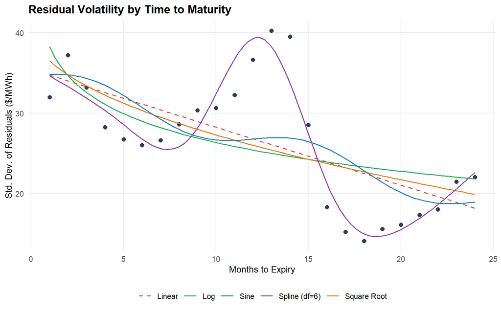

3. A predictive distribution of standardized residuals, based on the conditional mean $\hat{\mu}_{m,h}$ , conditional variance $\hat{\sigma}^2_{m,h,f}$, and each observed residual $e_i$

   $$z_i = \frac{e_i - \hat{\mu}_{m, h}}{\hat{\sigma}_{m,h,f}}$$

where:

- $\hat{\mu}_{m,h}$ is the predicted mean forecast error for delivery month $m$ at horizon $h$
- $e_i$ is the observed forecast error
- $\hat{\mu}_{m, h}$ is the fitted mean error from the error model
- $\hat{\sigma}_{m,h,f}$ is the fitted standard deviation from the volatility model

  If the standardized residuals were centered well above or below 0 for a particular season, the error model would be systematically over-or under-predicting errors for that group. If the spread were drastically wider or narrower for a particular season, then the volatility model would not be capturing the difference in uncertainty across months.

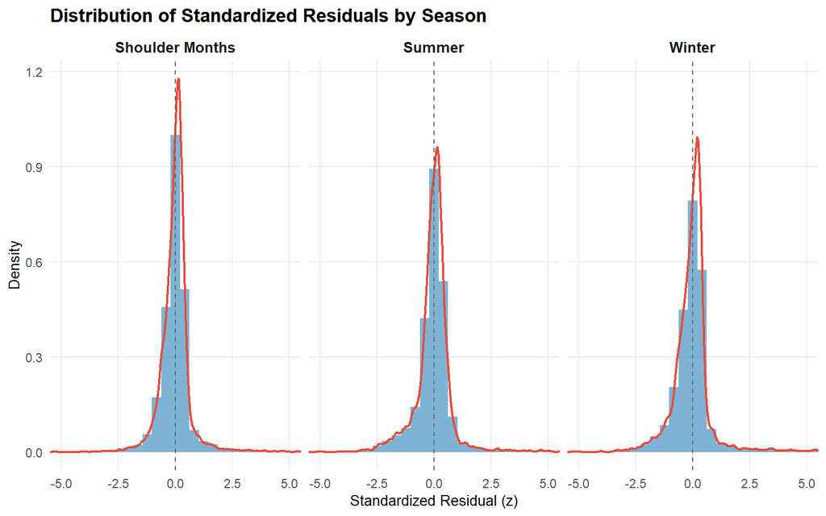

To account for this, the empirical distribution of the residuals is approximated separately depending on the expiration season of the contract. This ensures that the shape of the residual distribution reflects the varying characteristics of summer, winter, and shoulder month errors. For each season, kernel density estimation (KDE) is used to fit a smooth, continuous density curve to the observed values of $z$. The CDF is then derived, mapping each value of $z$ to the probability that a standardized residual falls below it. We invert the CDF to produce a function that maps a random draw $u$ from a Uniform distribution $U(0,1)$ to its corresponding value of $z$.

$$z = F^{-1}(u)$$

A Monte Carlo simulation follows: Take 10,000 uniform draws and pass them through the CDF to get 10,000 draws of $z$ that follow the empirical shape of the standardized residual distribution for that contract’s expiration season.

Finally, the simulated settlement price is computed as

$$\tilde{S} = f + \hat{\mu}_{m,h} + \hat{\sigma}_{m,h,f} \cdot z$$
where:

- $\tilde{S}$ is a simulated settlement price
- $f$ is the current futures price
- $\hat{\mu}_{m,h}$ is the predicted mean error from the error model
- $\hat{\sigma}_{m,h,f}$ is the predicted standard deviation from the volatility model
- $z$ is a draw from the seasonal empirical inverse CDF

Note that the error model is fitted twice for numerical stability. The base error model is fitted first, and its residuals are used to train the volatility model. Including the rolling mean at this stage explains enough additional variance that some of the residuals become near-zero, causing GLM’s fitting algorithm to destabilize. The rolling mean is added to the error in a second pass, replacing the base error model and leaving the other model components untouched. It is important to highlight that this creates a minor inconsistency, where the volatility was calibrated on base residuals that are slightly larger than the rolling mean model residuals. In practice, this results in wider prediction intervals, which is an acceptable outcome for a consumer risk tool.

## 4 Diagnostics

**Coverage**

The first metric used to evaluate the model is coverage. Essentially, coverage encapsulates the proportion of model prediction intervals that contained the month’s settled average DA LMP, given a specific month and horizon. For instance, take the expiration month March, and a horizon of 7 months. The model will predict a price distribution for every for every historical observation which matches those criteria, using the futures price at the time. If the realized price falls within the distribution, that observation is covered. The coverage for a particular month/horizon combination is $\frac{\text{\# covered}}{\text{\# total observations}}$ . Since the “Best” outcome cutoff is the 5th percentile, and the “Worst” cutoff is the 90th percentile, we would hope that at least 85% of historical observations are covered by the model. If a month/horizon combination is “too narrow”, than means less than 80% of its historical outcomes were covered.

Model Calibration by Forecast Horizon (Target: 85%)

| Horizon | Mean Coverage | Narrow Intervals |
| --- | --- | --- |
| Short (1–6 months) | 0.968 | 0.0% |
| Medium (7–12 months) | 0.969 | 0.0% |
| Long (13–24 months) | 0.941 | 4.2% |
| Very Long (25+ months) | 0.817 | 22.0% |

Based on the table, all horizon groups seem to have roughly 94-97% coverage, which is encouraging and well above the expected coverage. The only exception is very long horizons with a mean coverage of 0.817, which makes sense given the distance to settlement and uncertainty surrounding those contracts. The narrow interval percentage for short, medium, and long horizons ranges from 0-4.2%. This figure is strong, and it means that the model is effectively capturing the ranges of outcomes for horizons 2 years or less. It is obvious that model performance deteriorates for very long horizons, but given the time to settlement, the performance is still positive.

**Bias**

The next diagnostic is bias, which reveals whether the model is systematically over-or under-predicting in any given delivery month. A T-statistic above 2 or below -2 means the error model has a statistically significant directional bias for that month.

Bias Diagnostic by Delivery Month (|T-Stat| > 2 indicates significant bias)

| Delivery Month | Mean Bias | Std. Dev. | T-Statistic |
| --- | --- | --- | --- |
| Jan | 0.161 | 22.656 | 0.290 |
| Feb | 0.072 | 20.406 | 0.147 |
| Mar | 0.017 | 7.405 | 0.098 |
| Apr | -0.004 | 4.669 | -0.035 |
| May | 0.001 | 3.157 | 0.020 |
| Jun | -0.001 | 2.739 | -0.008 |
| Jul | 0.024 | 6.508 | 0.128 |
| Aug | -0.001 | 3.470 | -0.014 |
| Sep | -0.016 | 1.676 | -0.365 |
| Oct | -0.009 | 2.464 | -0.136 |
| Nov | 0.029 | 5.764 | 0.195 |
| Dec | 0.071 | 19.963 | 0.141 |

None of the months have a T-statistic above 2 or below -2, so the model passes the bias check.

**Point Forecast Accuracy**

The final way to evaluate model performance is to examine whether or not the base case prediction is actually better than the futures price alone as a point forecast for a given contract. A model “win” occurs when the base case lands closer to the settlement than the futures price. This diagnostic directly tests whether the error model’s mean adjustment adds value.

Point Forecast Accuracy vs Futures Price

| Month | N | Model MAE | Futures MAE | Model Beats Futures |
| --- | --- | --- | --- | --- |
| Jan | 1662 | 13.50 | 45.97 | 85.4% |
| Feb | 1748 | 11.44 | 32.93 | 80.4% |
| Mar | 1829 | 4.04 | 23.11 | 98.1% |
| Apr | 1915 | 2.82 | 7.19 | 70.3% |
| May | 1998 | 2.06 | 5.65 | 81.7% |
| Jun | 1179 | 1.78 | 4.50 | 75.6% |
| Jul | 1241 | 4.36 | 11.43 | 86.5% |
| Aug | 1308 | 2.15 | 10.28 | 91.7% |
| Sep | 1374 | 1.10 | 5.84 | 93.3% |
| Oct | 1438 | 1.41 | 3.48 | 72.5% |
| Nov | 1506 | 3.74 | 12.43 | 74.8% |
| Dec | 1578 | 12.78 | 40.05 | 84.0% |

Based on the results in the table above, the model beats the futures price as a point forecast in every single month, ranging from 70.3% of the time (April) to 98.1% (March). This supports the claim that the error model is adding value over simply using the futures price as the expected settlement value.

**Baseline comparison**

To justify the model’s complexity, it was benchmarked against 3 simple baselines:

- Baseline A - Futures Price + Historical Quantiles
  - This applies the historical 5th and 90th percentile of forecast errors directly to the current futures price, without accounting for any other factors. It is the simplest baseline, asking whether the model beats using the futures price and a fixed historical error band.
- Baseline B - Month $\times$ Horizon Bucket Lookup
  - This computes the 5th, 50th, and 90th percentile of historical forecast errors for each combination of delivery month and horizon bucket (0-3, 4-6, 7-12, 13-24, and 25+ months out) and applies them directly to the current futures price. This captures the two most obvious sources of structure in the data (seasonality and time to expiration) without any additional model complexity.
- Baseline C - Full Mean Model + Fixed Seasonal Residual Quantiles
  - This uses the full mean error model but replaces the Gamma GLM volatility model. After subtracting the mean model prediction from each historical error, the 5th and 90th percentiles of the residuals are calculated separately for each season and then applied to the base case. Every contract within a season receives the same interval width regardless of horizon or futures price level. This directly evaluates whether the Gamma GLM’s contract-specific variance predictions add measurable value.

Model vs Baseline Comparison — Recent Period Performance (2024-2026)

| model | Coverage | Mean Width | MAE | Bias | Pinball p05 | Pinball p50 | Pinball p90 |
| --- | --- | --- | --- | --- | --- | --- | --- |
| A: Futures + Historical Quantiles | 0.657 | 72.5 | 18.32 | 17.57 | 3.56 | 9.16 | 2.86 |
| B: Month x Horizon Bucket | 0.211 | 44.2 | 32.91 | 32.31 | 3.36 | 16.46 | 20.96 |
| C: Mean Model + Empirical Residuals | 0.655 | 49.1 | 9.83 | 9.48 | 2.47 | 4.91 | 2.86 |
| Full Model | 0.965 | 44.0 | 8.01 | 7.18 | 1.52 | 4.00 | 1.54 |

The full model outperforms all three baselines across every metric when tested on data from 2024-2026. Coverage of 96.5% is 31 percentage points higher than the next best baseline, despite having the most narrow mean interval width. The MAE is $1.82/MWh lower than the next closest figure, and pinball loss at all three quantiles is lower than every baseline. Baseline B’s coverage of 0.211 demontstrates the importance of the rolling mean adjustment. Without the adjustment, 2022-2023 historical error quantiles are applied to the lookup table. January 2023 futures were $294 and settled at $49, so that -$245 errror gets averaged into the January bucket, distorting all predictions. The rolling mean adjustement anchors predictions to recent market conditions. Baseline C’s coverage of 0.655 supports the decision to use the Gamma GLM. Empirical residual quantiles alone do not scale uncertainty appropriately across delivery month, horizon, and futures price levels.

## 5 Results

**Interpreting the Distributions**

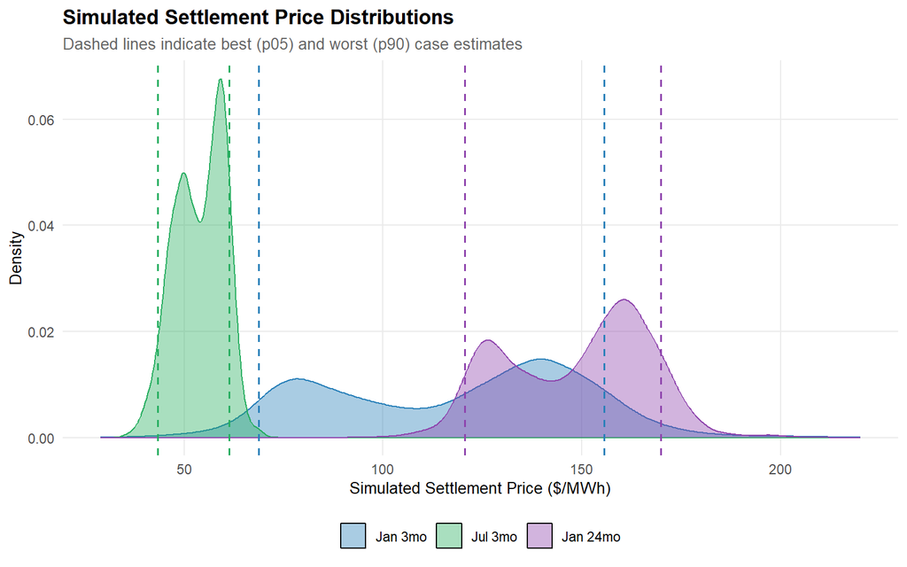

Sample Forecast Output

| Month | Months Out | Futures Price | Volatility ($/MWh) | Best Case (p05) | Base Case (p50) | Worst Case (p90) |
| --- | --- | --- | --- | --- | --- | --- |
| Jan | 3 | 100 | 32.05 | 68.69 | 124.72 | 155.70 |
| Jul | 3 | 48 | 6.26 | 43.39 | 54.44 | 61.36 |
| Jan | 24 | 115 | 17.95 | 120.54 | 152.51 | 169.94 |

**Assumptions, Limitations, and Future Work**